# 5663354

# Data Distribution and Visualization

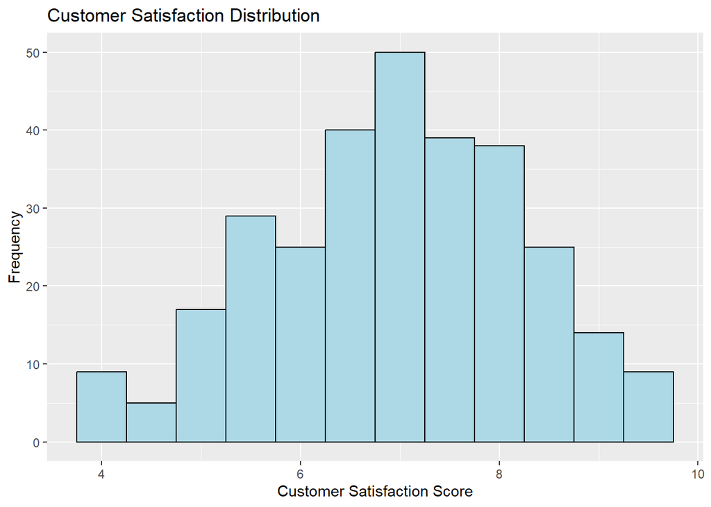

```r
# Visualize the distribution of customer satisfaction
ggplot(data, aes(x = customer.satisfaction)) +
  geom_histogram(binwidth = 0.5, fill = "lightblue", color = "black") +
  labs(title = "Customer Satisfaction Distribution", x = "Customer Satisfaction Score", y = "Frequency")
```

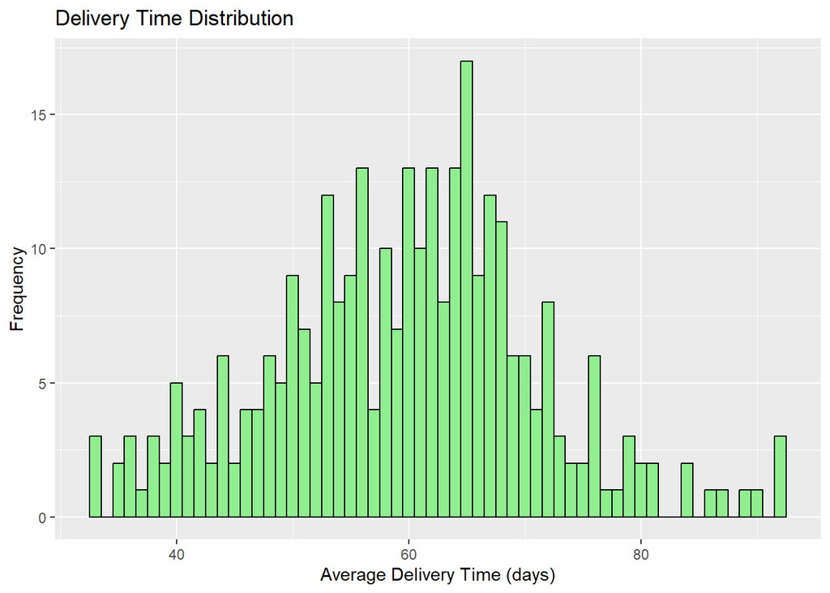

```r
# Visualize the distribution of delivery time
ggplot(data, aes(x = delivery.time)) +
  geom_histogram(binwidth = 1, fill = "lightgreen", color = "black") +
  labs(title = "Delivery Time Distribution", x = "Average Delivery Time (days)", y = "Frequency")
```

By visualizing the distributions, we gain a better understanding of the characteristics of the key variables.

## 1.Histogram of Customer Satisfaction

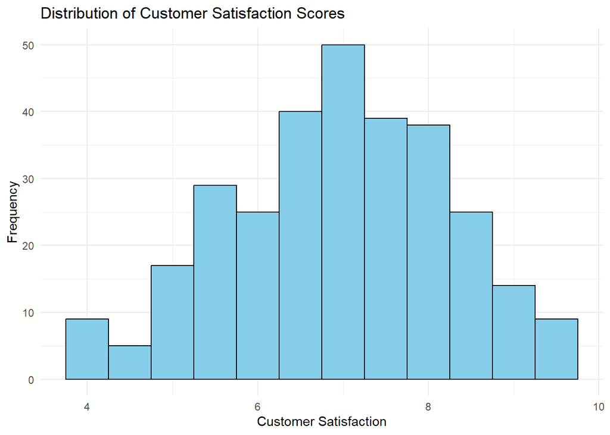

```r
# Histogram of Customer Satisfaction Scores
ggplot(data, aes(x = customer.satisfaction)) +
  geom_histogram(binwidth = 0.5, fill = "skyblue", color = "black") +
  labs(title = "Distribution of Customer Satisfaction Scores", x = "Customer Satisfaction", y = "Frequency") +
  theme_minimal()
```

This histogram will show how customer satisfaction scores are distributed across the stores.

## 2.Boxplot of Customer Satisfaction by SES Category

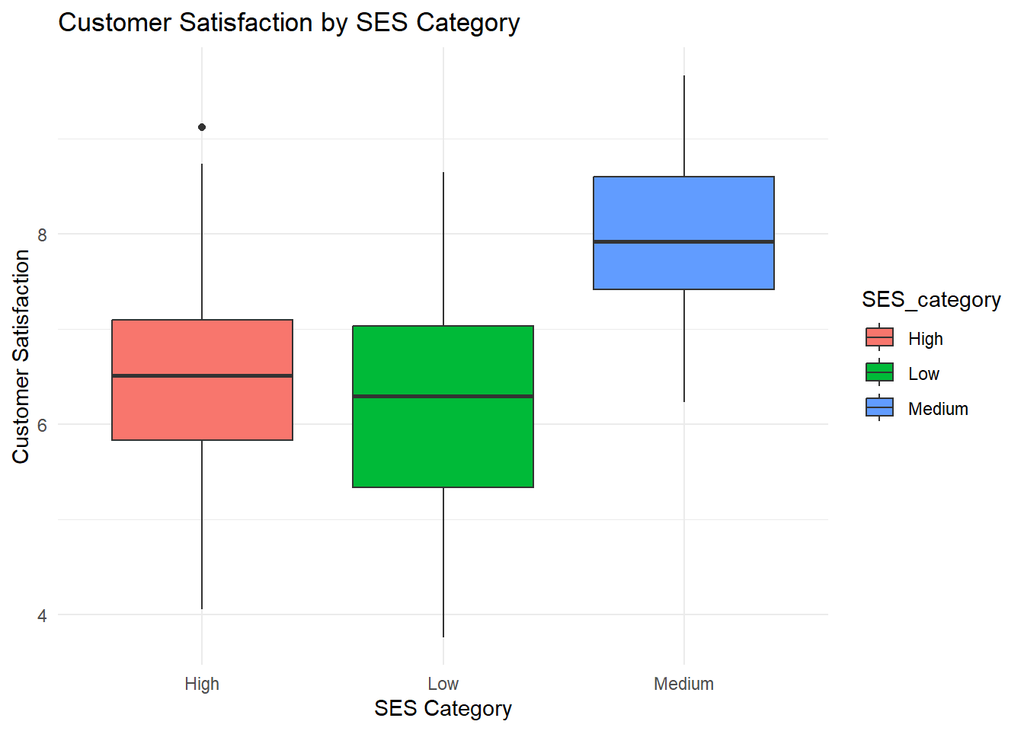

```r
# Boxplot of Customer Satisfaction by SES Category
ggplot(data, aes(x = SES_category, y = customer.satisfaction, fill = SES_category)) +
  geom_boxplot() +
  labs(title = "Customer Satisfaction by SES Category", x = "SES Category", y = "Customer Satisfaction") +
  theme_minimal()
```

This boxplot will help us understand the variation in customer satisfaction scores across different socio-economic categories (low, medium, high).

## 3.Scatter Plot of Delivery Time vs Customer Satisfaction

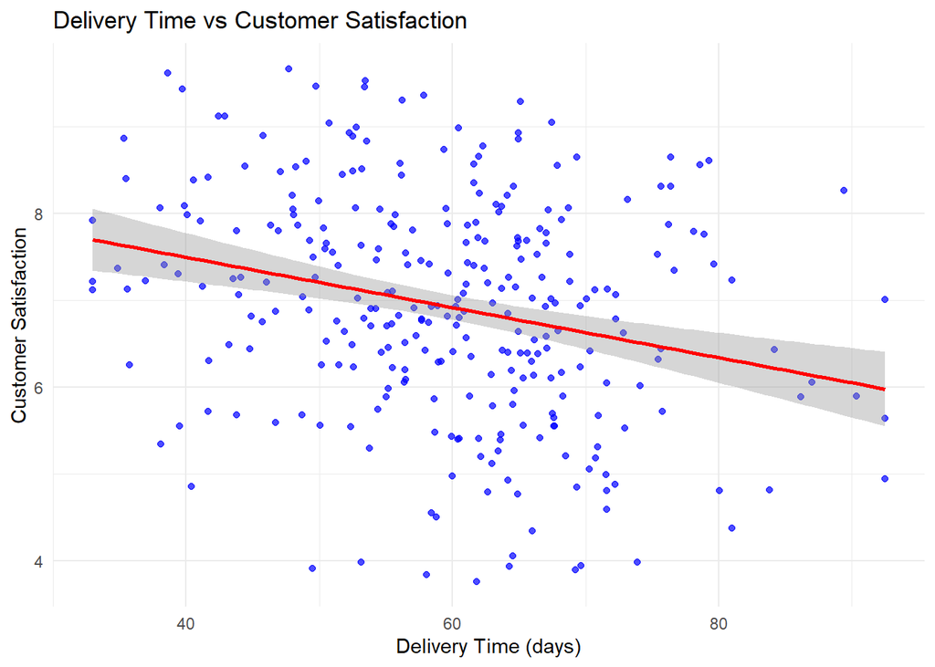

```r
# Scatter Plot of Delivery Time vs Customer Satisfaction
ggplot(data, aes(x = delivery.time, y = customer.satisfaction)) +
  geom_point(color = "blue", alpha = 0.7) +
  geom_smooth(method = "lm", se = TRUE, color = "red") +
  labs(title = "Delivery Time vs Customer Satisfaction", x = "Delivery Time (days)", y = "Customer Satisfaction") +
  theme_minimal()
```

This scatter plot shows the relationship between delivery.time and customer.satisfaction. The red line represents a linear regression fit to assess any trends in the data.

## 4.Density Plot of Customer Satisfaction by SES

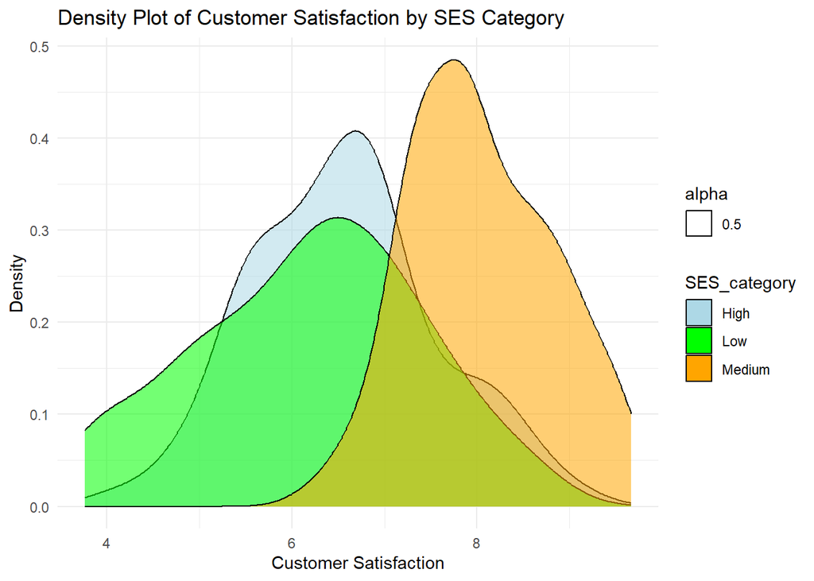

```r
# Density Plot of Customer Satisfaction by SES Category
ggplot(data, aes(x = customer.satisfaction, fill = SES_category, alpha = 0.5)) +
  geom_density() +
  labs(title = "Density Plot of Customer Satisfaction by SES Category", x = "Customer Satisfaction", y = "Density") +
  scale_fill_manual(values = c("lightblue", "green", "orange")) +
  theme_minimal()
```

This density plot visualizes the distribution of customer satisfaction scores for each SES category. It helps in understanding the shape of the distribution and comparing distributions across different SES categories.

# Correlation Analysis

```r
# Calculate the correlation matrix for the numeric variables
cor_matrix <- cor(data %>% select(customer.satisfaction, delivery.time, staff.satisfaction))
print(cor_matrix)
```

```
##                       customer.satisfaction delivery.time staff.satisfaction
## customer.satisfaction             1.0000000   -0.25890017         0.45404708
## delivery.time                    -0.2589002    1.00000000        -0.06520613
## staff.satisfaction                0.4540471   -0.06520613         1.00000000
```

By calculating correlations, we can identify which variables are most strongly associated with customer satisfaction.

# Statistical Analysis: Regression Modeling

```r
# Linear regression model to predict customer satisfaction
model <- lm(customer.satisfaction ~ delivery.time + SES_category + staff.satisfaction + new_range, data = data)

# Model summary
summary(model)
```

```
##
## Call:
## lm(formula = customer.satisfaction ~ delivery.time + SES_category +
##     staff.satisfaction + new_range, data = data)
##
## Residuals:
##      Min       1Q   Median       3Q      Max
## -2.59866 -0.67952 -0.01176  0.65469  2.89231
##
## Coefficients:
##                     Estimate Std. Error t value Pr(>|t|)
## (Intercept)         5.218333   0.610361   8.550 6.87e-16 ***
## delivery.time      -0.017220   0.004948  -3.480 0.000577 ***
## SES_categoryLow    -0.255765   0.138541  -1.846 0.065878 .
## SES_categoryMedium  1.209293   0.147773   8.183 8.43e-15 ***
## staff.satisfaction  0.351113   0.080457   4.364 1.77e-05 ***
## new_rangeTRUE       0.093878   0.112249   0.836 0.403643
## ---
## Signif. codes:  0 '***' 0.001 '**' 0.01 '*' 0.05 '.' 0.1 ' ' 1
##
## Residual standard error: 0.9687 on 294 degrees of freedom
## Multiple R-squared:  0.447,  Adjusted R-squared:  0.4376
## F-statistic: 47.53 on 5 and 294 DF,  p-value: < 2.2e-16
```

By running this model, we quantify how different factors contribute to customer satisfaction.

# Interaction Effects: Delivery Time and SES

```r
# Linear regression model with interaction between delivery time and SES category
interaction_model <- lm(customer.satisfaction ~ delivery.time * SES_category + staff.satisfaction + new_range, data = data)

# Model summary
summary(interaction_model)
```

```
##
## Call:
## lm(formula = customer.satisfaction ~ delivery.time * SES_category +
##     staff.satisfaction + new_range, data = data)
##
## Residuals:
##      Min       1Q   Median       3Q      Max
## -2.69336 -0.63905 -0.02235  0.64181  2.70571
##
## Coefficients:
##                                   Estimate Std. Error t value Pr(>|t|)
## (Intercept)                       6.293471   0.751004   8.380 2.26e-15 ***
## delivery.time                    -0.036301   0.009168  -3.960 9.44e-05 ***
## SES_categoryLow                  -2.225232   0.750829  -2.964  0.00329 **
## SES_categoryMedium               -0.001146   0.742808  -0.002  0.99877
## staff.satisfaction                0.359605   0.079847   4.504 9.67e-06 ***
## new_rangeTRUE                     0.104057   0.111400   0.934  0.35103
## delivery.time:SES_categoryLow     0.032463   0.012156   2.670  0.00800 **
## delivery.time:SES_categoryMedium  0.020282   0.012478   1.625  0.10514
## ---
## Signif. codes:  0 '***' 0.001 '**' 0.01 '*' 0.05 '.' 0.1 ' ' 1
##
## Residual standard error: 0.9603 on 292 degrees of freedom
## Multiple R-squared:  0.4602, Adjusted R-squared:  0.4473
## F-statistic: 35.57 on 7 and 292 DF,  p-value: < 2.2e-16
```

This step allows us to explore more complex relationships in the data, providing deeper insights into how delivery time and SES interact.

# ANOVA (Analysis of Variance)

## 1.ANOVA for SES Category and Customer Satisfaction

```r
# Perform ANOVA to check the effect of SES_category on customer satisfaction
anova_ses <- aov(customer.satisfaction ~ SES_category, data = data)
summary(anova_ses)
```

```
##               Df Sum Sq Mean Sq F value Pr(>F)
## SES_category   2  193.2   96.58   93.83 <2e-16 ***
## Residuals    297  305.7    1.03
## ---
## Signif. codes:  0 '***' 0.001 '**' 0.01 '*' 0.05 '.' 0.1 ' ' 1
```

We will perform an ANOVA test to see if the SES category (low, medium, high) significantly impacts customer satisfaction.

## 2.ANOVA for New Range and Customer Satisfaction

```r
# Perform ANOVA to check the effect of new_range on customer satisfaction
anova_new_range <- aov(customer.satisfaction ~ new_range, data = data)
summary(anova_new_range)
```

```
##              Df Sum Sq Mean Sq F value Pr(>F)
## new_range     1    1.3   1.259   0.754  0.386
## Residuals   298  497.6   1.670
```

Similarly, we can check if the presence of a new product range (TRUE/FALSE) affects customer satisfaction.